# Informe Primer Semestre 2021

Ciencias

Claudio Rojas. Director Académico

2021-07-31

## 0.1 Presentación

El presente informe tiene como objetivo revisar el trabajo del sector, a través de información que sistematiza los resultados académicos del I semestre y recoge lo proyectado para el II semestre del presente año, considerando las definiciones claves que tenemos como colegio pero también como una institución de la Compañía de Jesús.

Este informe incluye:

- Definiciones Clases
- Informe de Notas
- Metas de Aprendizaje.
- Propuestas de Evaluación II Semestre.

Cada una de las partes de informe incluye sugerencias que bucan orientar la reflexión y práctica del sector para poder realizar los ajustes que sean necesarios para el trabajo de la segunda parte del presente año.

## 0.2 Definiciones Claves

Les recuerdo tener presente las definiciones claves tanto a nivel de red ignaciana como interna que deben siempre orientar nuestro trabajo académico.

### 0.2.1 Envío 3 Planificación Estratégica de los colegios Jesuitas

Asegurar que los 10 colegios y escuelas jesuitas desarrollen las prácticas y procesos necesarios para ofrecer la excelencia académica propia de una comprensión ignaciana de la educación de calidad.

### 0.2.2 Nuestra Definición de Calidad

Nosotros, como comunidad sanjavierina, entendemos por educación de calidad todo aprendizaje que nos lleva a descubrir y desarrollar nuestras capacidades de manera integral, formándonos como personas competentes, conscientes, comprometidas, compasivas y creativas, para así conocer y amar más y mejor a Jesucristo, sirviendo a nuestros hermanos en los diversos contextos sociales.

### 0.2.3 Nuestro Foco de Mejora

Fortalecer la propuesta curricular, con una didáctica renovada, bajo el Paradigma Pedagógico Ignaciano.

## 0.3 Informe de Notas

El informe de notas contiene la siguiente información:

- Tabla de Resumen de las notas por nivel.
- Notas de 1º básico a IVº medio.
- Distribución por Niveles de Logro.

En el caso de los resultados, les sugiero analizar:

- Los promedios finales obtenidos por cada nivel
- Cantidad de estudiantes que están en cada nivel de logro.
- Las diferencias de resultados entre hombres y mujeres.

### 0.3.1 Tabla de Resumen de Notas:

Cada tabla incluye la siguiente información de la asignatura por nivel:

- Promedio de la asignatura.
- Nota Mínima.
- Mediana.
- Nota Máxima.

#### 0.3.1.1 Tabla 1: Ciencias Naturales /Biología (Primero básico a Cuarto medio)

[output not shown]

#### 0.3.1.2 Tabla 2: Fisica (Primero a Cuarto Medio)

| Nivel | Promedio | Mediana | NotaMínima | NotaMáxima |
| --- | --- | --- | --- | --- |
| 9 | 6.3 | 6.3 | 3.5 | 7 |
| 10 | 6.0 | 6.0 | 1.7 | 7 |
| 11 | 6.8 | 6.8 | 5.1 | 7 |
| 12 | 6.9 | 6.9 | 6.4 | 7 |

#### 0.3.1.3 Tabla 3: Química (Primero a Cuarto Medio)

| Nivel | Promedio | Mediana | NotaMínima | NotaMáxima |
| --- | --- | --- | --- | --- |
| 9 | 6.40 | 6.40 | 2.1 | 7 |
| 10 | 6.40 | 6.40 | 3.5 | 7 |
| 11 | 6.55 | 6.55 | 4.4 | 7 |
| 12 | 6.90 | 6.90 | 4.2 | 7 |

### 0.3.2 Notas de 1º básico a IVº medio

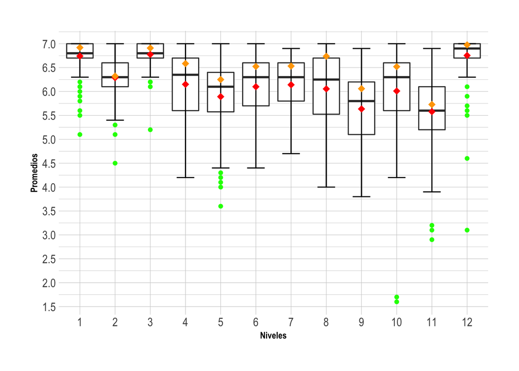

### 0.3.3 Distribución de Estudiantes por Niveles de Logro y diferenciado por Sexo.

#### 0.3.3.1 Primeros Básicos

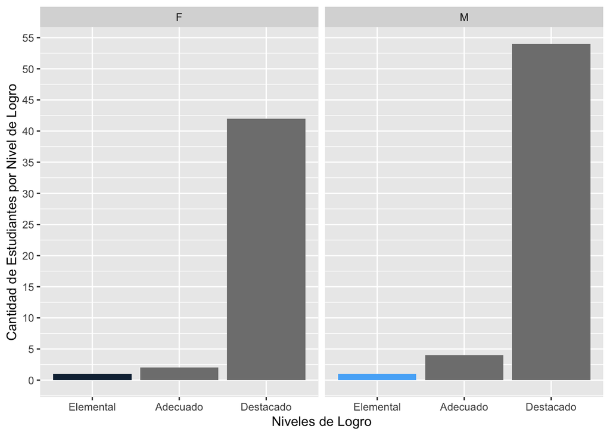

### 0.3.4 Segundos Básicos

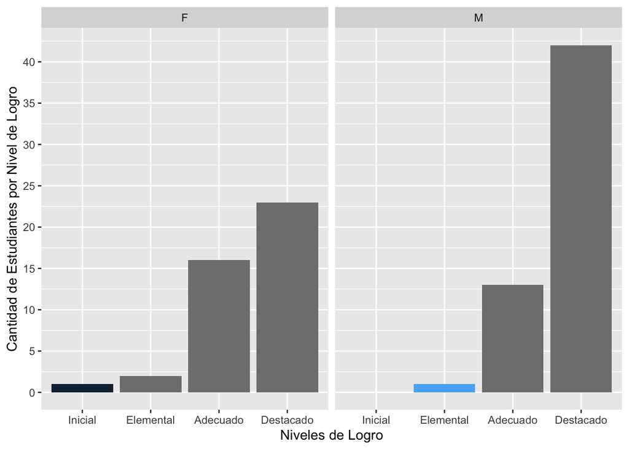

#### 0.3.4.1 Terceros Básicos

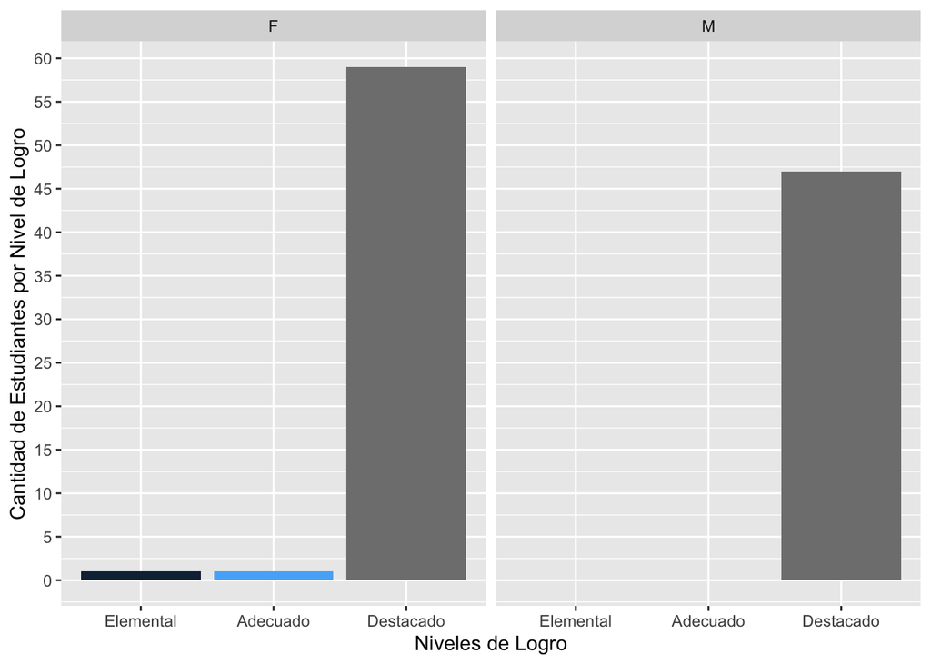

#### 0.3.4.2 Cuartos Básicos

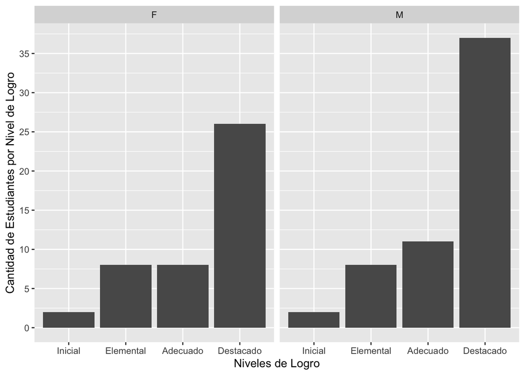

#### 0.3.4.3 Quintos Básicos

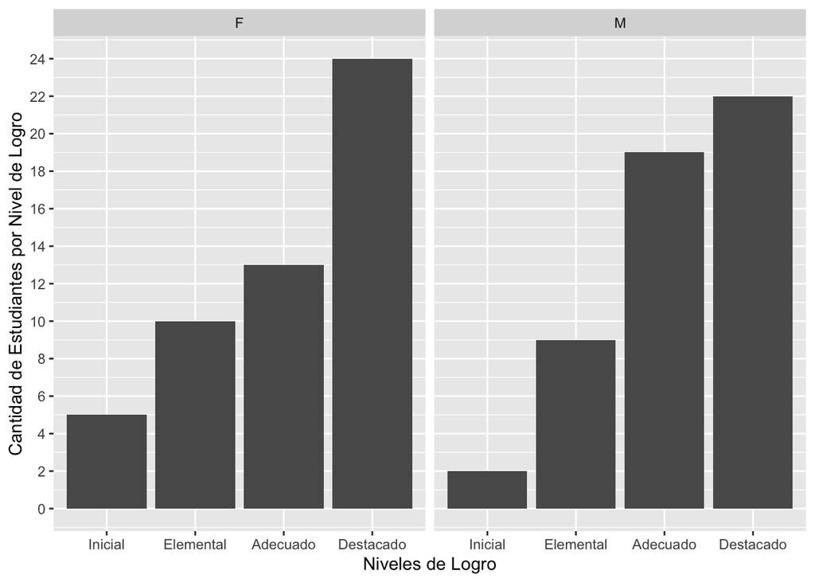

#### 0.3.4.4 Sextos Básicos

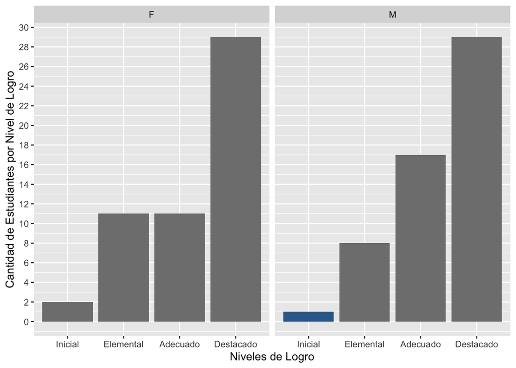

#### 0.3.4.5 Séptimos Básicos

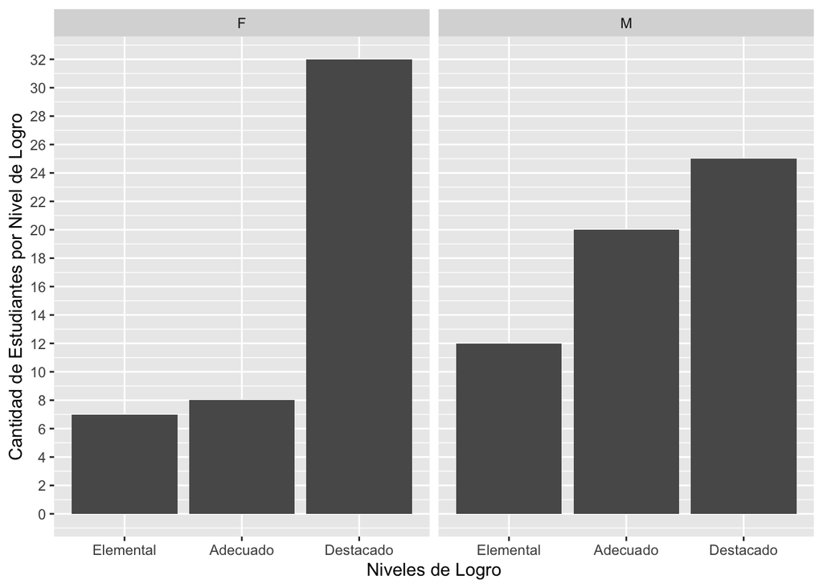

#### 0.3.4.6 Octavos Básicos

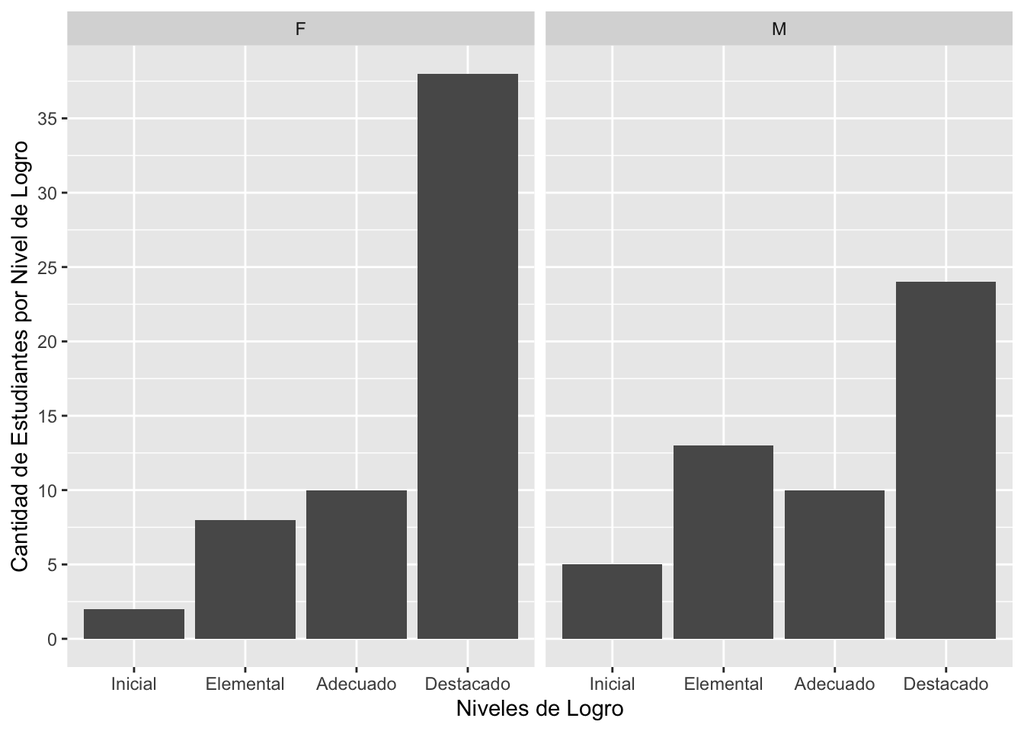

#### 0.3.4.7 Primeros Medios Biología

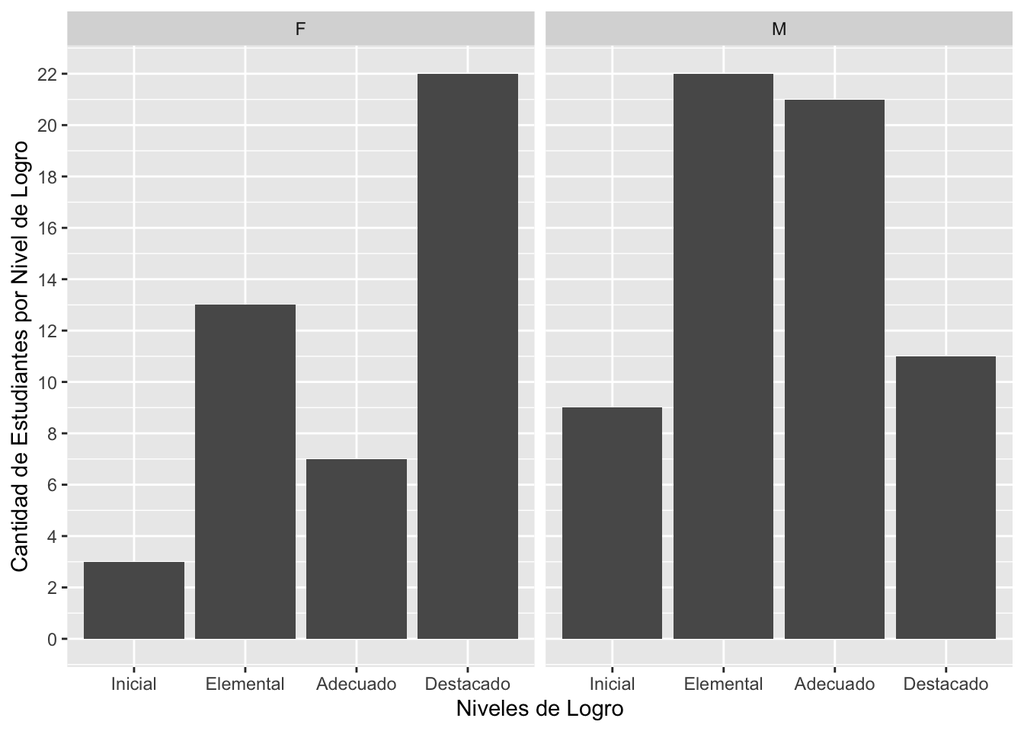

#### 0.3.4.8 Primeros Medios Física

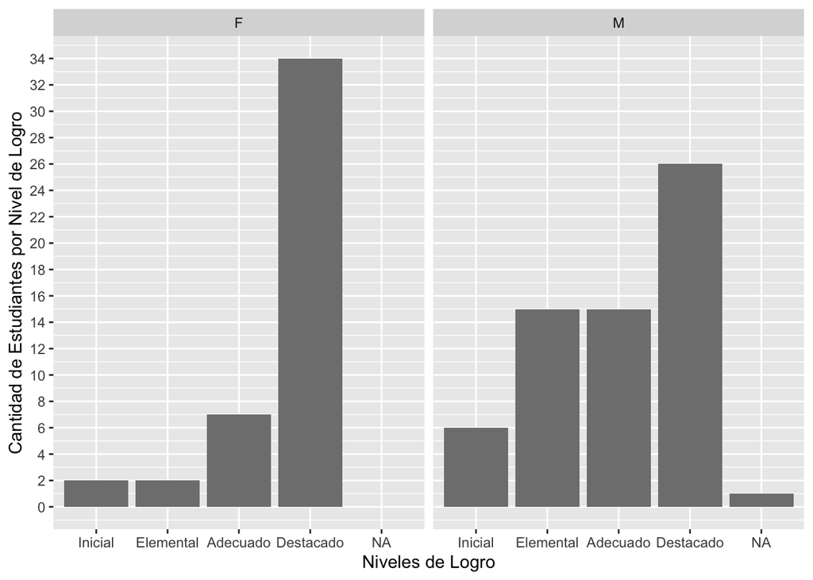

#### 0.3.4.9 Primeros Medios Química

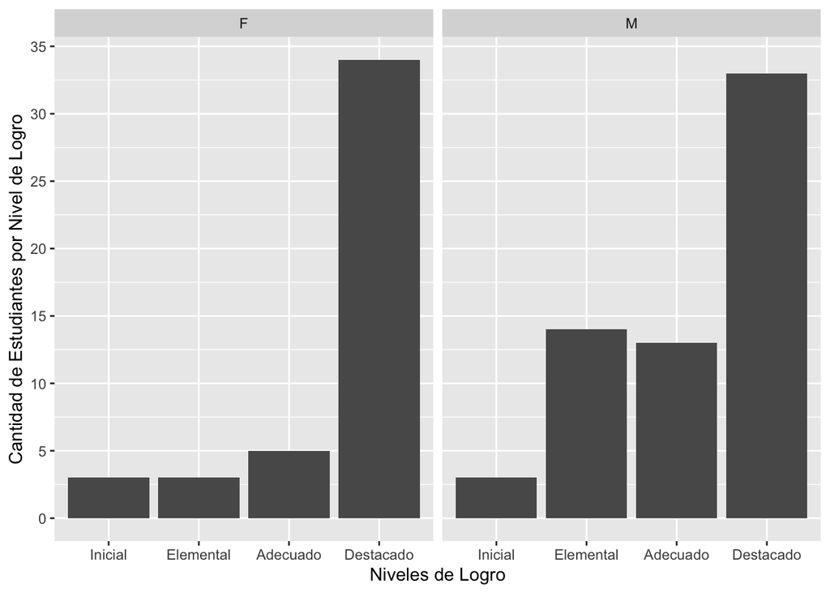

#### 0.3.4.10 Segundos Medios Biología

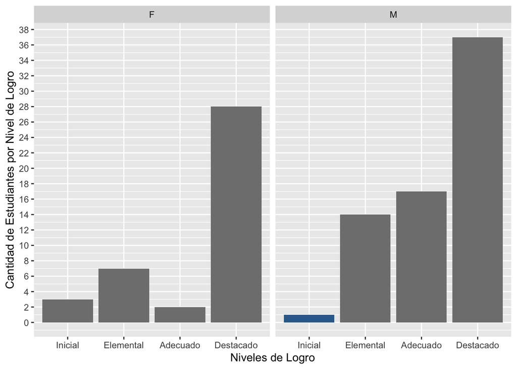

#### 0.3.4.11 Segundos Medios Física

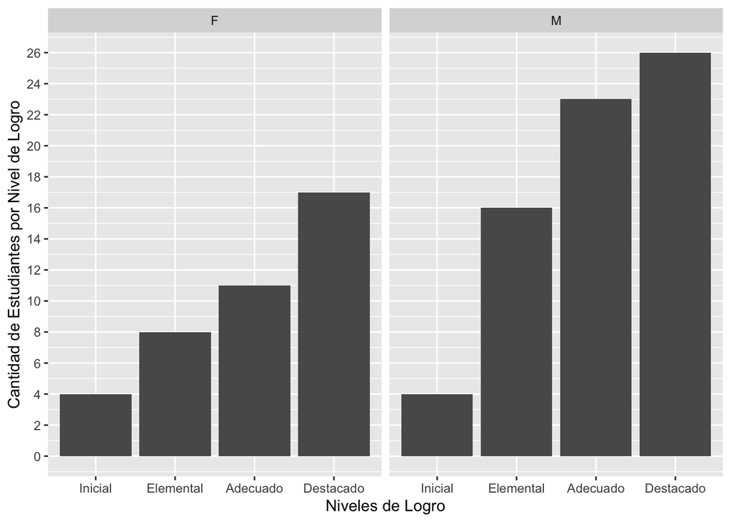

#### 0.3.4.12 Segundos Medios Química

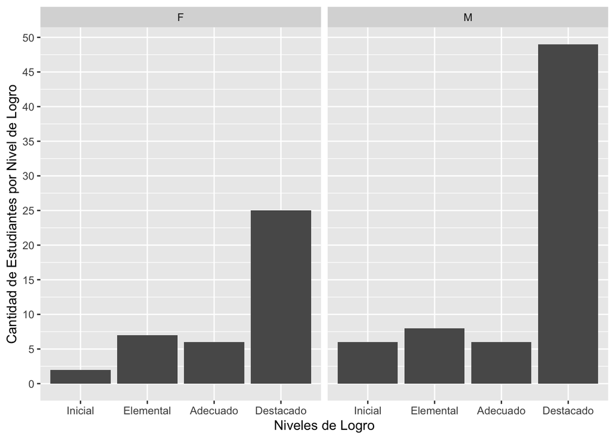

#### 0.3.4.13 Terceros Medio

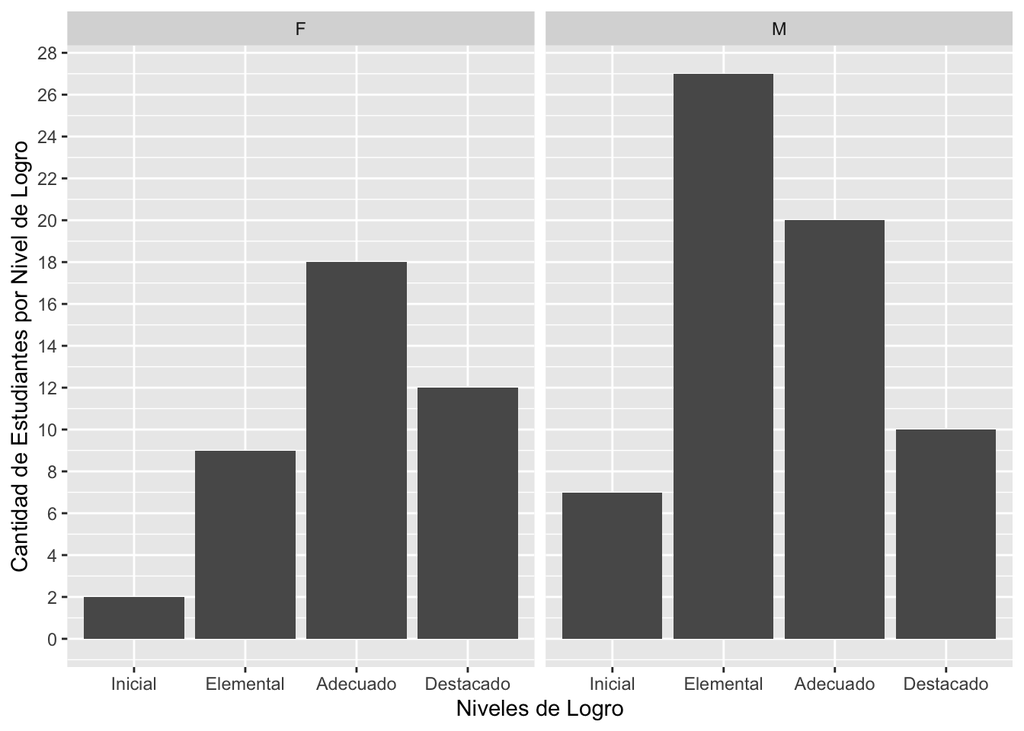

#### 0.3.4.14 Cuartos Medios

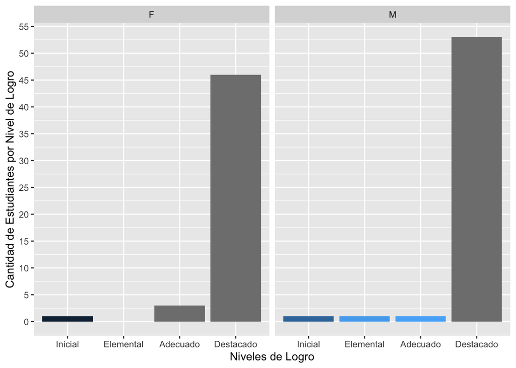

## 0.4 Metas de Aprendizajes

Se incluye las Metas de Ciencias Naturales y Biología, Física y Química. En el caso de estas dos últimas, las referidas a primero y segundo medio. Ajustar las metas considerando los siguientes criterios:

- **¿Contienen errores gramaticales:** **Redacción, Faltas de Ortografía** **?**
- **¿Están escritas de manera clara y precisa?** Ejemplo: *“Observen e investiguen de forma experimental, las funciones de cada una de las partes de la planta. Asimismo, deberán formular preguntas y predicciones sobre las necesidades vitales de las plantas y acerca de las principales transformaciones que experimentan durante su ciclo de vida, reconociendo su importancia para la vida de los seres vivos y el medio ambiente siendo conscientes de la importancia de usar adecuadamente los recursos.”* **Revisar la escritura de metas ya que más parece una suma de OA**
- **¿Se usan los verbos adecuados?** Ejemplo: *“Comprenden,a través de la exploración y la investigación, que existen elementos vivos y no vivos en los diversos ecosistemas de Chile, y que los seres vivos poseen adaptaciones que les permiten vivir en determinado lugar existiendo una diversidad de interacciones como las cadenas alimentarias, y como estas pueden ser modificadas por la actividad humana.(Cuarto básico)”* . **En este caso, hay tres verbos y quizás solo con el de Investigación es suficiciente. Corregir este tipo de metas.**
- **¿Las metas expresan aprendizajes relevantes que deben adquirir mis estudiantes?** Ejemplo: *“Describir los aportes de cientificas chilenas y cientificos chilenos en la astronomía y el resto del mundo (Primero medio - Física)”*. **Esto más que una meta parece un objetivo que forma parte de una meta?**
- **Poner atención en metas excesivamente largas que resultan ser una suma de objetivos más que una meta?** Ejemplos: **Metas de 5º, 6º y 7º básico.**
- **Ajustar las metas que contengan verbos que son poco precisos a la hora de medir:** *Comprender, Reflexionar*. **Pero también, aquellas que contengan verbos que den cuenta de niveles básicos de aprendizaje:** *Identificar, Reconocer, Describir*. **Las metas de aprendizajes deben ser** *Medibles* **pero también** *Desafiantes*.

### 0.4.1 Metas de Aprendizajes Primer Ciclo

| Nivel | Segunda Unidad | Tercera Unidad |
| --- | --- | --- |
| Primero Básico | Identifiquen, exploren y pongan en acción sus habilidades científicas, concientizando las herramientas de exploración de su entorno y su propio cuerpo. Serán capaces de profundizar en sus 5 sentidos y… | Comprenderán la importancia del cuidado y autocuidado de su propio cuerpo y el de los demás, experimentando y aprendiendo hábitos de vida saludable respecto a su alimentación, higiene y ejercicio físi… |
| Segundo básico | Los estudiantes comprenderán la importancia de cuidar los principales órganos de su cuerpo dada la función que cumplen en nuestro organismo, valorando el beneficio que tiene el autocuidado y la vida s… | Los estudiantes comprenderán la importancia del agua como elemento vital y trascendental para la vida en nuestro planeta. |

### 0.4.2 Metas de Aprendizajes Segundo Ciclo

| Nivel | Segunda Unidad | Tercera Unidad |
| --- | --- | --- |
| Tercero básico | Observen e investiguen de forma experimental, las funciones de cada una de las partes de la planta. Asimismo, deberán formular preguntas y predicciones sobre las necesidades vitales de las plantas y a… | Describir los componentes del Sistema Solar y explicar, por medio de actividades prácticas, los movimientos de la Tierra por medio de modelos, además de conocer sucesión de fases de la Luna y eclipses… |
| Cuarto básico | Comprenden,a través de la exploración y la investigación, que existen elementos vivos y no vivos en los diversos ecosistemas de Chile, y que los seres vivos poseen adaptaciones que les permiten vivir … | Comprendan que el movimiento corporal del ser humano es provocado por la interacción coordinada entre músculos, huesos y tendones coordinada por el sistema nervioso, incorporando los efectos negativos… |
| Quinto básico | Conozcan diferentes formas en se manifiesta la energía, que comprendan la conformación de un circuito eléctrico simple, que distingan entre materiales conductores y no conductores y que en definitiva,… | Comprendan los diferentes niveles de organización de los seres vivos, desde la célula hasta la totalidad del organismo. En este marco, se espera que los estudiantes aprendan algunas características de… |
| Sexto básico | Comprendan las características de las capas de la Tierra y de los distintos tipos de suelo. En este punto es importante que comprendan las relaciones de interdependencia entre los seres vivos y el sue… | Explicar la pubertad como una etapa del desarrollo en la que ocurren una serie de cambios en hombres y mujeres, comprendiendo que el cuidado del cuerpo requiere practicar un estilo de vida saludable (… |

### 0.4.3 Metas de Aprendizajes Tercer y Cuarto Ciclo

| Nivel | Segunda Unidad | Tercera Unidad |
| --- | --- | --- |
| Séptimo básico | Explicar el desarrollo de un nuevo individuo considerando aspectos biológicos femeninos y masculinos,incorporando la responsabilidad y autocuidado que el cuerpo requiere. | Describir el funcionamiento general del sistena inmune del organismo en función de agentes patógenos que pueden estimular una respuesta inmunitaria de las barreras defensivas, reconociendo los benefic… |
| Octavo básico | Expliquen la interacción sistémica corporal, considerando: El rol del sistema excretor en relación con la filtración de la sangre, la regulación de la cantidad de agua en el cuerpo y la eliminación de… | Expliquen las interacciones que pueden ocurrir entre dos cuerpos cargados eléctricamente, refiriéndose a la ley de atracción y repulsión. Analizarán circuitos eléctricos simples y aquellos que tienen … |
| Primero medio | Analizar el flujo de materia y energía considerando la transferencia que se produce en las redes y tramas tróficas entre organismos y en relación con su ambiente por medio de los ciclos biogeoquímicos… | Explicar cómo se organizan e interactúan los seres vivos en diversos ecosistemas, considerando interacciones biológicas intraespecíficas e interespecíficas (como depredación, competencia, comensalismo… |
| Segundo medio | Explicar la transmisión de la herencia genética a partir de los principios básicos propuestos por Mendel. | Analizar el funcionamiento endocrino en la coordinación de procesos fisiológicos que requieren de la acción conjunta de diversos órganos y sistemas, usando el proceso de reproducción y el control de l… |
| Cuarto Medio | Analizar qué factores biológicos, ambientales y sociales influyen en la salud humana y cómo la medicina convencional y tradicional de los pueblos originarios ayudan a resolver problemas de salud cotid… | Analizar mediante evidencias, la transmisión de agentes infecciosos en Chile y el mundo, mencionando ejemplos, evaluando en forma crítica las medidas de prevención como el uso de vacunas. |

### 0.4.4 Metas de Aprendizajes Iº y IIº medio Física

| Nivel | Segunda Unidad | Tercera Unidad |
| --- | --- | --- |
| Primero Medio | Comprender el mundo natural y tecnológico a partir del estudio de fenómenos relacionados con la reflexión y la refracción de la luz. Es relevante que sean capaces de predecir sobre el comportamiento d… | Describir los aportes de cientificas chilenas y cientificos chilenos en la astronomía y el resto del mundo. |
| Segundo Medio | Comprender que, para describir el movimiento de un cuerpo, se requiere de un sistema de referencia, que se escoge de manera arbitraria y según conveniencia, en situaciones cotidianas y cercanas, y las… | Comprender los efectos que provocan las fuerzas sobre los cuerpos en los que actúan, así como las leyes de la naturaleza que se relacionan con ellas, como los principios de Newton en diversas situacio… |

### 0.4.5 Metas de Aprendizajes Iº y IIº medio Química

[output not shown]

## 0.5 Plan de Evaluación IIº semestre 2021

En la siguiente tabla se presentan los procedimientos e instrumentos declarados por el sector (1º básico en adelante) y la cantidad de veces que se repiten. Revisar lo declarado en el plan de evaluación considerando los siguientes criterios:

- **¿Hay claridad en el sector entre lo que es un procedimiento y su diferencia con el instrumento?** **En el caso de dudas, revisar nuestro [Reglamento de Evaluación](https://www.colsanjavier.cl/files/documentos/REGLAMENTO%20INTERNO%20DE%20EVALUACIÓN%202021.%20%5Bv.%2030-04-2021%5D.pdf).**
- **Es importante revisar los instrumentos o procedimientos que se utilizarán, ya que lo declarado** *favorece una práctica más tradicional de la evaluación del aprendizaje: guía, prueba, test.*

Por último, se agrega una nube de palabras que quiere reflejar la diversidad de instrumentos y el peso de cada uno de ellos.

|  | word | freq |
| --- | --- | --- |
| prueba | prueba | 31 |
| investigación | investigación | 17 |
| test | test | 8 |
| prototipo | prototipo | 7 |
| ensayopdt | ensayopdt | 4 |
| guiaejercicios | guiaejercicios | 4 |
| actividadclase | actividadclase | 3 |
| trabajo | trabajo | 3 |
| informeavance | informeavance | 2 |
| ejercicios | ejercicios | 1 |
| fichareforzamiento | fichareforzamiento | 1 |
| guia | guia | 1 |
| guiaclase | guiaclase | 1 |
| quizz | quizz | 1 |
| actividadejercicios | actividadejercicios | 1 |
| exposición | exposición | 1 |
| modelo | modelo | 1 |
| proyecto | proyecto | 1 |
| disertación | disertación | 1 |

[interactive chart not shown]

En el caso del **Plan de Nivel**, les solicito que como sector concuerden y plasmen en la planificación

- En qué sesiones se evaluarán el OA que se hace responsable el sector.
- El instrumento que usarán para concretar esta evaluación.

Es importante que ustedes como jefes de sector hagan sequimiento de este proceso, ya que es el medio con el cual concretamos la formación integral. Pero, además, los resultados obtenidos, es lo que informamos a los estudiantes y sus familias en los distintos objetivos de aprendizajes asociados a las tres dimensiones de nuestro Mapa de Formación Integral.